# Design & Analysis workshop

Priscila López-Beltrán Forcada

Spring 2021

In this session, we will learn and implement an extensive data cleaning protocol.

Let’s work on a real life example.

```r
monolingual_data <- read_csv("/Users/priscilalopez-beltran/Documents/Statistics workshop/MA_MONOLINGUALS_IA Report.csv")
```

We have a 2x2, repeated measures experiment where we want to test if there are differences in the processing of active and passive sentences depending on information structure (given-new vs. new-given).

These are the steps we’re going to follow in cleaning these data:

1. Graph the data
2. Remove trials with extreme values
3. Remove fixations outside IA
4. Remove trials with inaccurate answers to comprehension question
5. Log transform dependent variable
6. Remove outliers based on MAD
7. Graph data again

Let’s start

**1. Data visualization**

We visualize the raw data to check for normality of distribution. WHat do we see?

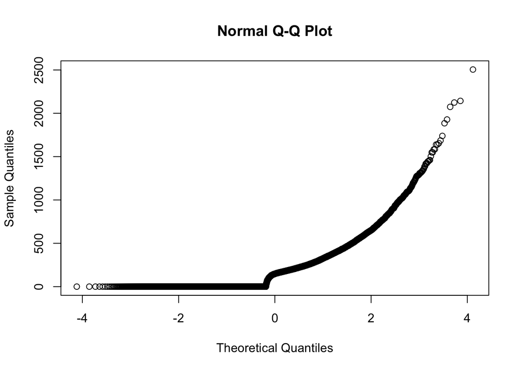

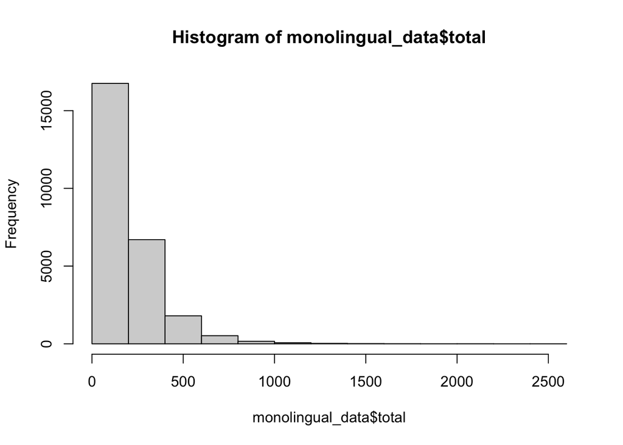

```r
qqnorm(monolingual_data$total, pch=1, fame=F)
hist(monolingual_data$total)
```

**2. Removal of extreme values**

```r
monolingual_data2 <- monolingual_data %>%
  filter(gaze > 120 & gaze < 3000 )
```

How many datapoints were removed?

```r
paste0(round(((length(monolingual_data$gaze) - length(monolingual_data2$gaze)) / length(monolingual_data$gaze))*100,2),"% of datapoints removed")
```

```
## [1] "56.58% of datapoints removed"
```

**3. Fixation removal**

For variables *first fixation duration* and *gaze duration*, we only want those values where *first fixation progressive* is 1. This means that the IA wasn’t skipped and then returned to; first fixation duration and gaze duration only count when the IA is read for *the first time from the left*. Here, we are removing trials where EITHER both IA1 and IA2 were skipped during first pass OR IA1 and IA2 were not read at all.

```r
# Total duration is 0
monolingual_data_agg2 <- droplevels(subset(monolingual_data_agg, total != 0))

# If the IA was not read or was skipped mark it as 1
monolingual_data_agg2$trial_exclude <- with(monolingual_data_agg2,ifelse((ia1_skipped == 1 & ia2_skipped == 1) | (ia1_notread == 1 & ia2_notread == 1), 1, 0))

# Subset only those trials where the IA were read for the first time from the left
monolingual_data_agg2 <- droplevels(subset(monolingual_data_agg2, trial_exclude == 0))

# How much data did we lose?
paste0(round(((length(monolingual_data_agg$total) - length( monolingual_data_agg2$total)) / length(monolingual_data_agg$total))*100,2),"% of datapoints removed")
```

```
## [1] "24.57% of datapoints removed"
```

**4. Remove inaccurate answers**

```r
monolingual_data_agg3 <- droplevels(subset(monolingual_data_agg2, question_accuracy == 1))

paste0(round(((length(monolingual_data_agg2$total) - length( monolingual_data_agg3$total)) / length(monolingual_data_agg3$total))*100,2),"% of datapoints removed")
```

```
## [1] "2.49% of datapoints removed"
```

**5. Log transform dependent variable**

When our original continuous data do not follow the “bell curve”, we can log transform this data to make it as “normal” as possible so that the statistical analysis results from this data become more valid. In other words, the log transformation reduces or removes the skewness of our original data.

Let’s visualize it:

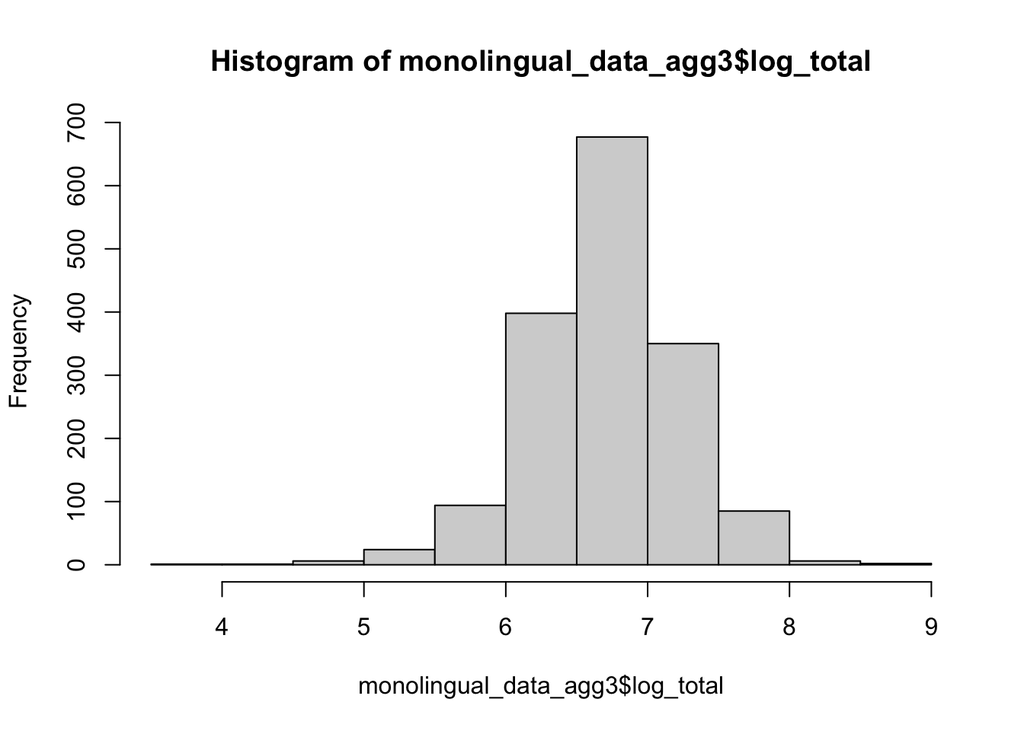

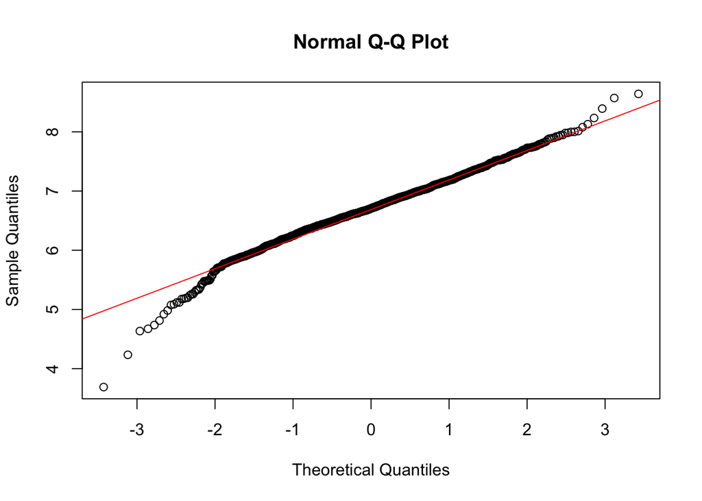

```r
monolingual_data_agg3$log_total <- log(monolingual_data_agg3$total)

# Let's visualize our data again
hist(monolingual_data_agg3$log_total)
qqnorm(monolingual_data_agg3$log_total)
qqline(monolingual_data_agg$log_total, col= "red")
```

**6. Outlier removal** If our data doesn’t look great yet (see qqplot), we’ll want to remove outliers. Here, I’ll remove outliers based on MAD scores (Median Absolute Deviation) derived from log total duration, only **by participant**. (See Levishina, 2015, ch.3)

```r
library(Rling)
monolingual_data_clean <- data.frame()
participants <- unique(monolingual_data_agg3$participant)

for(i in 1:length(participants)){
  x <- subset(monolingual_data_agg3, participant == participants[i])
  monolingual_data_clean <- rbind(monolingual_data_clean,
                                  subset(x, abs(normalize(log_total, method = "mad")) < 3))
}
rm(i, x, participants)


paste0(round(((length(monolingual_data_agg3$log_total) - length(monolingual_data_clean$log_total)) / length(monolingual_data_agg3$log_total))*100,2),"% of datapoints removed")
```

```
## [1] "1.7% of datapoints removed"
```

Let’s visualize one last time:

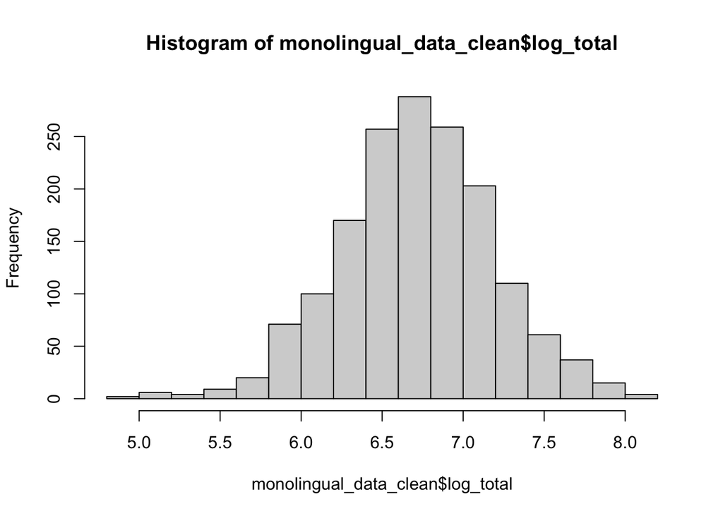

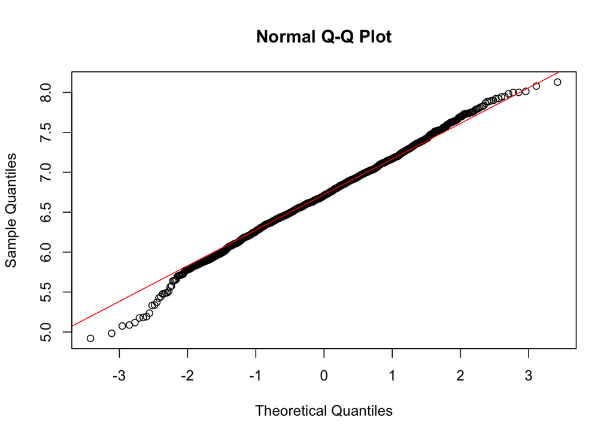

```r
hist(monolingual_data_clean$log_total)
qqnorm(monolingual_data_clean$log_total)
qqline(monolingual_data_clean$log_total, col= "red")
```

#### Resources

- Log-transformation
  - https://medium.com/@kyawsawhtoon/log-transformation-purpose-and-interpretation-9444b4b049c9
  - https://www.ncbi.nlm.nih.gov/pmc/articles/PMC4120293/
- Outlier removal
  - Baker & Wicherts (2014) Outlier removal, sum scores, and the inflation of the type I error rate in independent samples t tests: The power of alternatives and recommendations.
  - Leys et al., (2013) Detecting outliers: Do not use standard deviation around the mean, use absolute deviation around the median (
  - Nicklin & Plonsky (2020) Outliers in L2 Research in Applied Linguistics: A Synthesis and Data Re-Analysis
  - Osborne & Overbay (2004) The Power of Outliers (and Why Researchers Should Always Check for Them)